# Coursera Regression model

eric

March 29, 2016

## Exploratory

Because in liner regression there is a lot of assumption that depend on Gaussian distribution.So at the first ,we need to see there is highly skewed or not

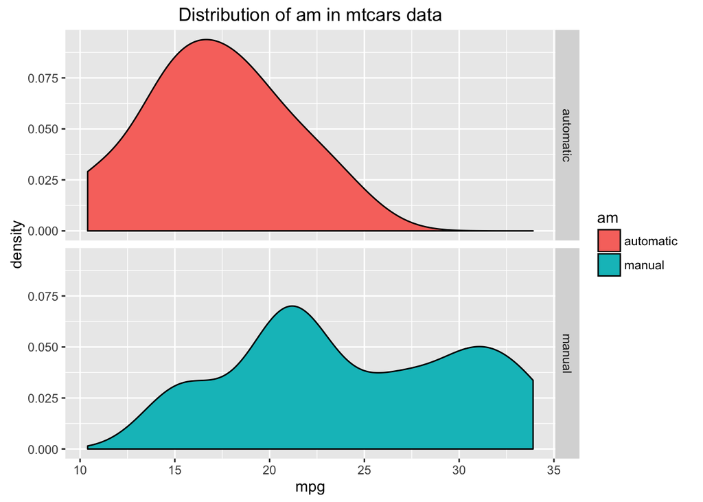

```r
data("mtcars")
library(ggplot2)
mtcars$am=as.factor(mtcars$am)
mtcars$am=ifelse(mtcars$am==1,"manual","automatic")
ggplot(mtcars,aes(x=mpg,fill=am))+geom_density(bw=2)+facet_grid(am~.)+ggtitle("Distribution of am in mtcars data")
```

It seems that the variate that we are most interested in is ok. Next:we check the other variates.

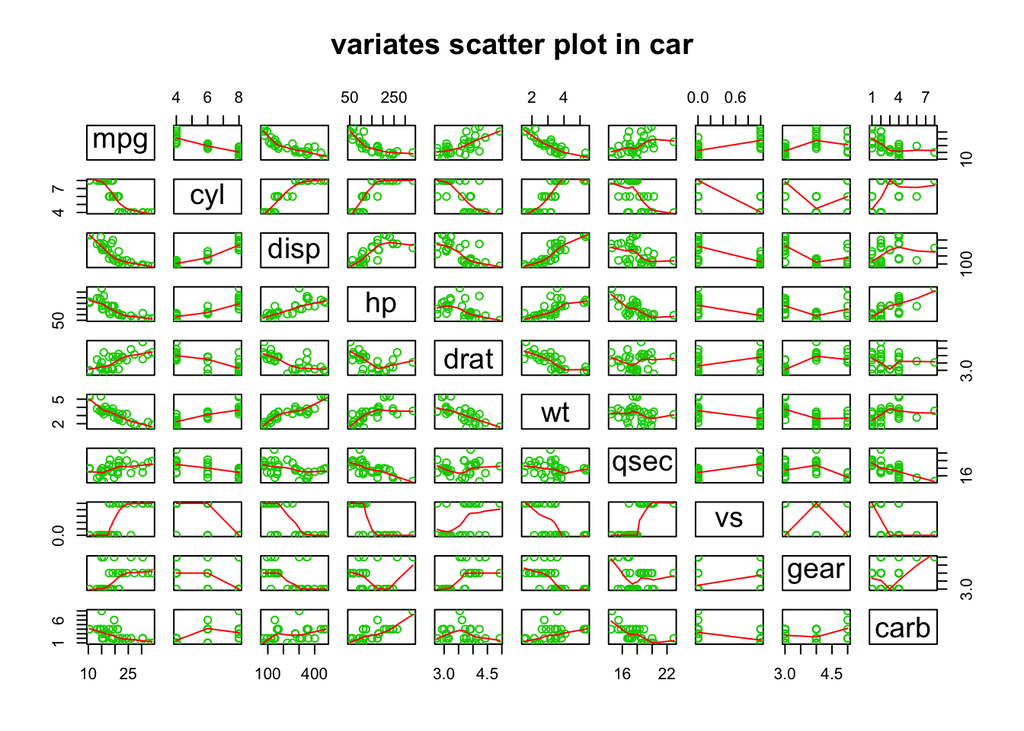

```r
pairs(mtcars[,-9], panel = panel.smooth, main = "variates scatter plot in car", col = 3)
```

## Make the models

first see the just one variate that we are interested.

```r
lm.fit.just.one<-lm(mpg~factor(am),data=mtcars)
summary(lm.fit.just.one)
```

```
##
## Call:
## lm(formula = mpg ~ factor(am), data = mtcars)
##
## Residuals:
##     Min      1Q  Median      3Q     Max
## -9.3923 -3.0923 -0.2974  3.2439  9.5077
##
## Coefficients:
##                  Estimate Std. Error t value Pr(>|t|)
## (Intercept)        17.147      1.125  15.247 1.13e-15 ***
## factor(am)manual    7.245      1.764   4.106 0.000285 ***
## ---
## Signif. codes:  0 '***' 0.001 '**' 0.01 '*' 0.05 '.' 0.1 ' ' 1
##
## Residual standard error: 4.902 on 30 degrees of freedom
## Multiple R-squared:  0.3598, Adjusted R-squared:  0.3385
## F-statistic: 16.86 on 1 and 30 DF,  p-value: 0.000285
```

Then use the nested models(put in the variable randomly) and other way to make model and compare it(some steps it’s for convenient to save time).

```r
lm.1<-lm(mpg~factor(am)+factor(cyl)+wt,data=mtcars)
lm.2<-lm(mpg~factor(am)+factor(cyl)+disp+hp+drat+wt+qsec,data=mtcars)
lm.multi<-lm(mpg~factor(cyl)+disp+hp+drat+wt+qsec+factor(vs)+factor(am)+factor(gear)+factor(carb),data=mtcars)
best_model <- step(lm.multi, direction = "both")
```

```
## Start:  AIC=76.4
## mpg ~ factor(cyl) + disp + hp + drat + wt + qsec + factor(vs) +
##     factor(am) + factor(gear) + factor(carb)
##
##                Df Sum of Sq    RSS    AIC
## - factor(carb)  5   13.5989 134.00 69.828
## - factor(gear)  2    3.9729 124.38 73.442
## - factor(am)    1    1.1420 121.55 74.705
## - qsec          1    1.2413 121.64 74.732
## - drat          1    1.8208 122.22 74.884
## - factor(cyl)   2   10.9314 131.33 75.184
## - factor(vs)    1    3.6299 124.03 75.354
## <none>                      120.40 76.403
## - disp          1    9.9672 130.37 76.948
## - wt            1   25.5541 145.96 80.562
## - hp            1   25.6715 146.07 80.588
##
## Step:  AIC=69.83
## mpg ~ factor(cyl) + disp + hp + drat + wt + qsec + factor(vs) +
##     factor(am) + factor(gear)
##
##                Df Sum of Sq    RSS    AIC
## - factor(gear)  2    5.0215 139.02 67.005
## - disp          1    0.9934 135.00 68.064
## - drat          1    1.1854 135.19 68.110
## - factor(vs)    1    3.6763 137.68 68.694
## - factor(cyl)   2   12.5642 146.57 68.696
## - qsec          1    5.2634 139.26 69.061
## <none>                      134.00 69.828
## - factor(am)    1   11.9255 145.93 70.556
## - wt            1   19.7963 153.80 72.237
## - hp            1   22.7935 156.79 72.855
## + factor(carb)  5   13.5989 120.40 76.403
##
## Step:  AIC=67
## mpg ~ factor(cyl) + disp + hp + drat + wt + qsec + factor(vs) +
##     factor(am)
##
##                Df Sum of Sq    RSS    AIC
## - drat          1    0.9672 139.99 65.227
```

[output cut: 59 more lines]

```
## Step:  AIC=61.65
## mpg ~ factor(cyl) + hp + wt + factor(am)
##
##                Df Sum of Sq    RSS    AIC
## <none>                      151.03 61.655
## - factor(am)    1     9.752 160.78 61.657
## + factor(vs)    1     7.346 143.68 62.059
## + qsec          1     7.044 143.98 62.126
## - factor(cyl)   2    29.265 180.29 63.323
## + disp          1     0.617 150.41 63.524
## + drat          1     0.220 150.81 63.608
## + factor(gear)  2     1.361 149.66 65.365
## - hp            1    31.943 182.97 65.794
## - wt            1    46.173 197.20 68.191
## + factor(carb)  5     5.633 145.39 70.438
```

```r
anova(lm.fit.just.one,lm.1,lm.2,best_model)
```

```
## Analysis of Variance Table
##
## Model 1: mpg ~ factor(am)
## Model 2: mpg ~ factor(am) + factor(cyl) + wt
## Model 3: mpg ~ factor(am) + factor(cyl) + disp + hp + drat + wt + qsec
## Model 4: mpg ~ factor(cyl) + hp + wt + factor(am)
##   Res.Df    RSS Df Sum of Sq       F    Pr(>F)
## 1     30 720.90
## 2     27 182.97  3    537.93 29.2064 5.085e-08 ***
## 3     23 141.21  4     41.76  1.7006    0.1842
## 4     26 151.03 -3     -9.82  0.5332    0.6641
## ---
## Signif. codes:  0 '***' 0.001 '**' 0.01 '*' 0.05 '.' 0.1 ' ' 1
```

It seems the model lm.1 is most significant ,and that it means when we add wt changes most!!But after we check Rss is lm.2 best. Check lm.2 solely.

```r
summary(lm.2)
```

```
##
## Call:
## lm(formula = mpg ~ factor(am) + factor(cyl) + disp + hp + drat +
##     wt + qsec, data = mtcars)
##
## Residuals:
##     Min      1Q  Median      3Q     Max
## -3.7362 -1.3973 -0.3513  1.4311  4.2267
##
## Coefficients:
##                   Estimate Std. Error t value Pr(>|t|)
## (Intercept)      17.475854  14.027771   1.246   0.2254
## factor(am)manual  2.748596   1.777155   1.547   0.1356
## factor(cyl)6     -1.697049   1.913301  -0.887   0.3843
## factor(cyl)8     -0.522560   3.464300  -0.151   0.8814
## disp              0.007572   0.013236   0.572   0.5728
## hp               -0.025353   0.015699  -1.615   0.1200
## drat              0.633293   1.479625   0.428   0.6726
## wt               -3.426768   1.323748  -2.589   0.0164 *
## qsec              0.718097   0.596598   1.204   0.2410
## ---
## Signif. codes:  0 '***' 0.001 '**' 0.01 '*' 0.05 '.' 0.1 ' ' 1
##
## Residual standard error: 2.478 on 23 degrees of freedom
## Multiple R-squared:  0.8746, Adjusted R-squared:  0.831
## F-statistic: 20.05 on 8 and 23 DF,  p-value: 1.206e-08
```

The model is significant,and it also verify that the most significant variate is wt.

### Residual plot

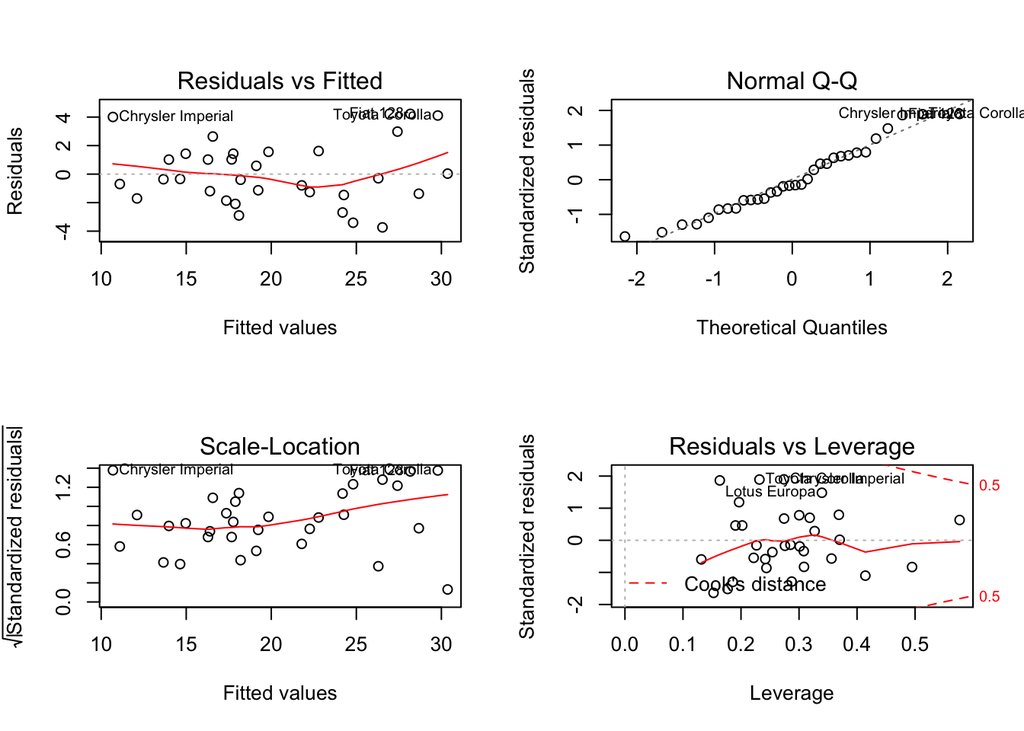

```r
par(mfrow = c(2, 2)); plot(lm.2)
```

We can see the model is good.

## Conclusion

: Then we chek most significant variate and the things that we are interesting.

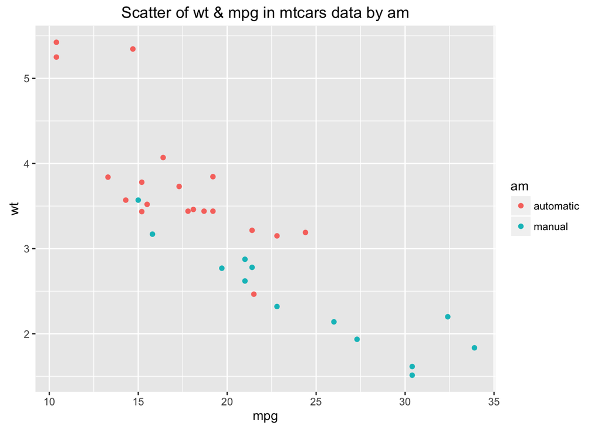

```r
ggplot(mtcars,aes(x=mpg,y=wt,color=am))+geom_point()+ggtitle("Scatter of wt & mpg in mtcars data by am")
```

It seems that can answer the question which we are interested in.